# Grout Mueseum Presentation

April 7, 2019

## Overview

The objective of this project is to provide a report about donation information relating to donations, revenue, and customers to try and improve knowledge of customer and/or donor base the Grout Museum has in order to better target that type of customer/donor or event.

## Outline

This presentation is meant for discussion topics. Analysis of the graphs will be brief. Further analysis can be found in the report to come.

- Software Used in Analysis
- Brief Description of the Donations Data
- Time Series Analysis
- Outlier Analysis
- Donor Type Analysis
- Zip-code Analysis
- Summary & Recommendations
- Further Studies

## Software Used in Analysis

- For the the donation analysis and report, R was used.
  - Allowed for easy manipulation of data.
  - Allowed for easy implementation of map data.
  - Allowed for creating a markdown report.
- For the Dashboard Excel was used
  - Allows for repeatable process.
  - Less technical skills needed.

## The Data

- The data provided was information about the donations that were received.
- Dates memberships were on sale.
- R data sets for map information were also pulled in.

```
## Observations: 554
## Variables: 4
## $ gift_amount <dbl> 50.00, 100.00, 500.00, 22.40, 50.00, 5100.00, 500....
## $ date        <dttm> 2018-01-31, 2017-12-20, 2018-02-23, 2017-07-05, 2...
## $ donor_type  <chr> "Business", "Individual", "Business", "Foundation"...
## $ zip         <chr> "50643", "50677", "50704", "01810", "50701", "5070...
```

## Time Series Analysis

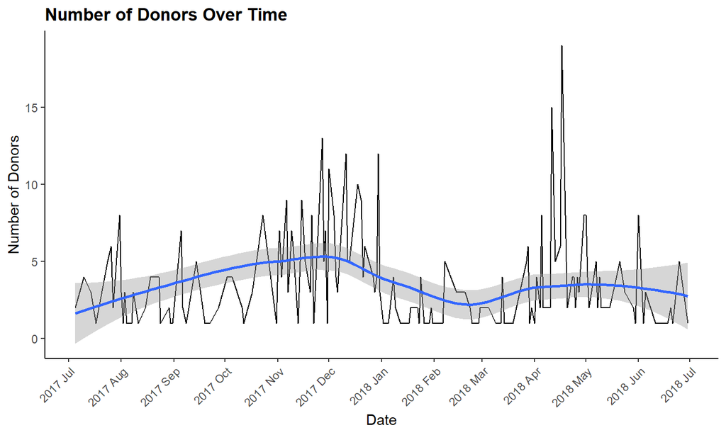

## Outlier Analysis

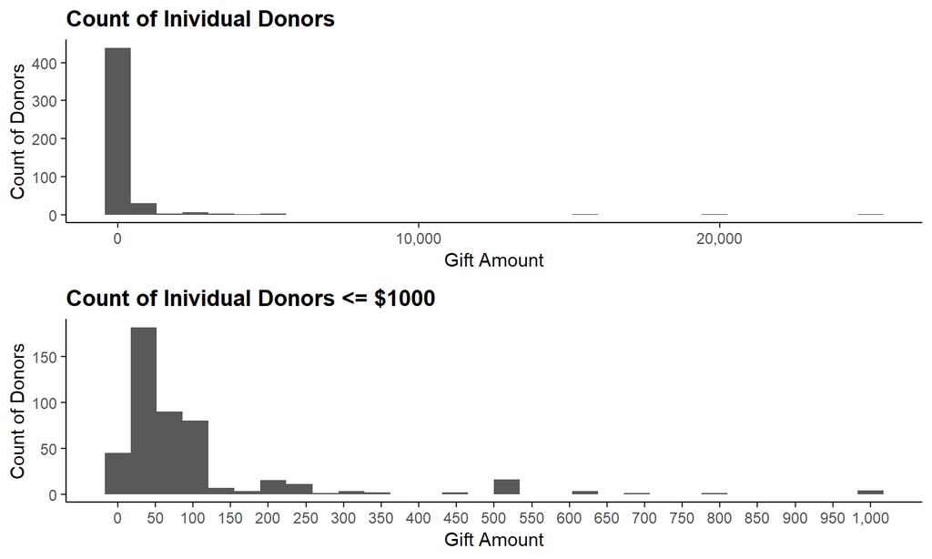

## Donors by Group

Count/Mean/Median of Donations by Donor Type

| donor_type | count | gift_mean | gift_mode |
| --- | --- | --- | --- |
| Business | 47 | $588.62 | $330 |
| Foundation | 9 | $10,291.39 | $10,000 |
| Fund/Estate | 6 | $5,249.92 | $3,168.30 |
| Individual | 485 | $310.92 | $53 |
| Organization | 7 | $874.42 | $200 |

## Donors by Quarter

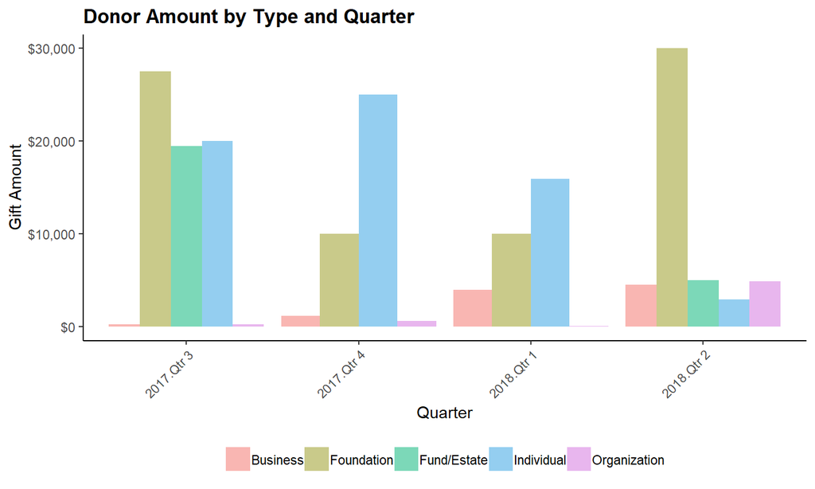

## Donors by Quarter - Cont'd

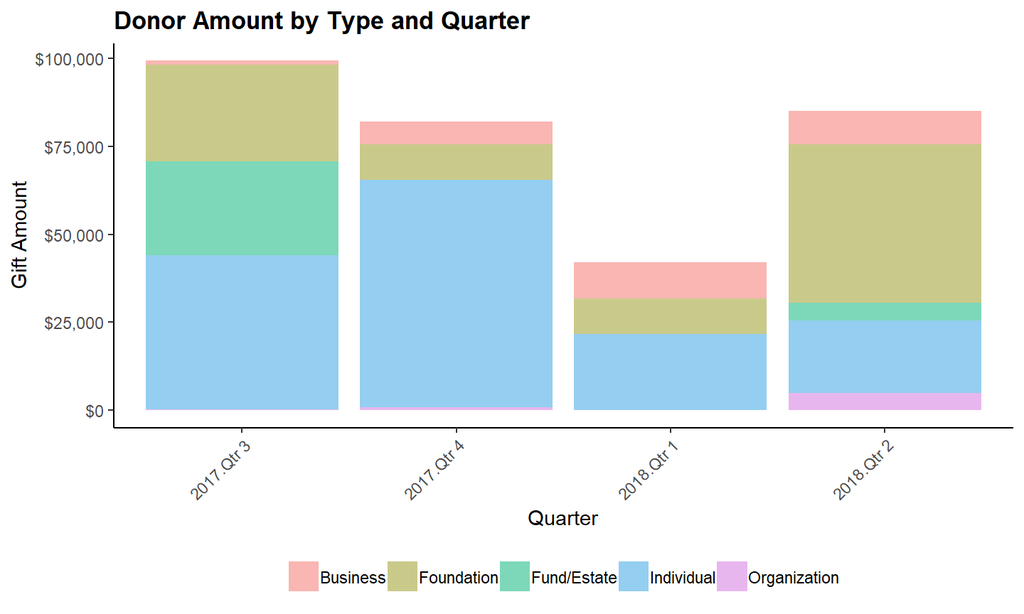

## Zip-code Analysis - Count

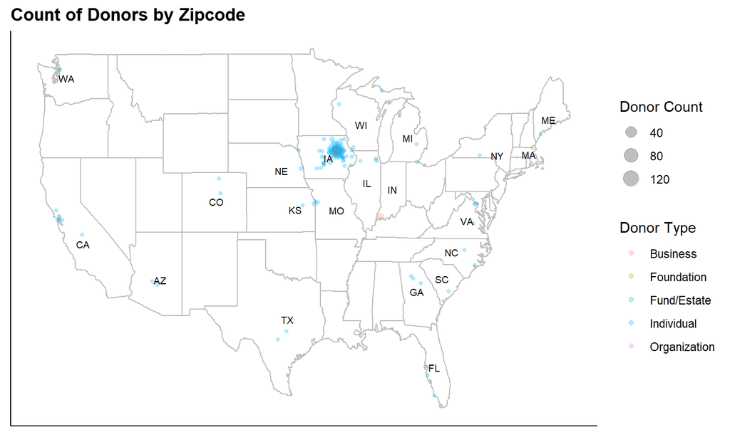

## Zip-code Analysis - Gift

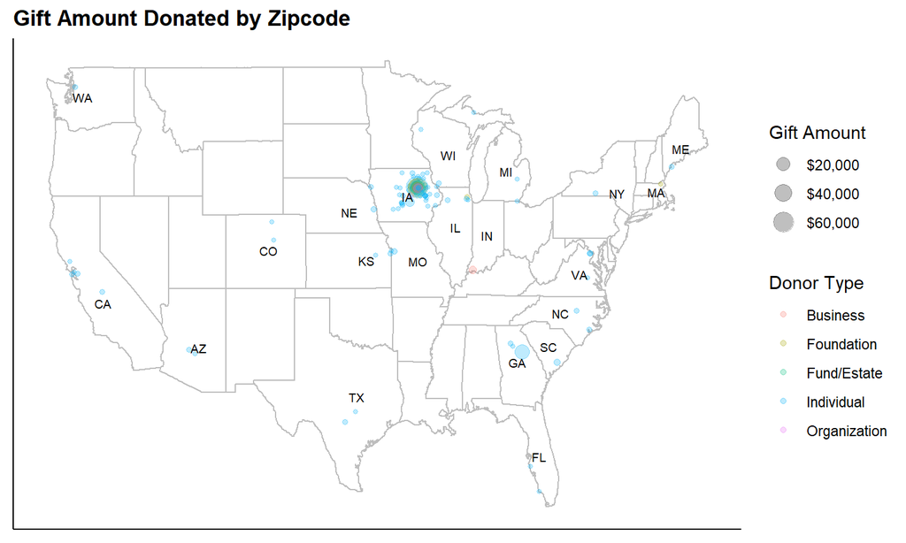

## Recommendations

My recommendation to the Grout Museum are to:

1. Strategize a way to collect entice individual donors to make $50 donations or more if you are not already doing so.
2. Strategize increase donations of individuals in 2nd quarter and all donations in 1st quarter.
3. Investigate the reason for donations from the south South East.

## Further Studies

- Look at Outcomes of Strategies Used for Collecting Donations
- Look at Membership and Customers Data
- Look at Longer Time Frame